# 01-Simple models

Francisco E. Fonturbel

26/mar/2022

## Anthropogenic effects on chungungo’s abundance

Here we will explore some anthropogenic variables as potential drivers of abundance change on this species

Let’s do some nice ggplots to examine our data before fitting fancy models:

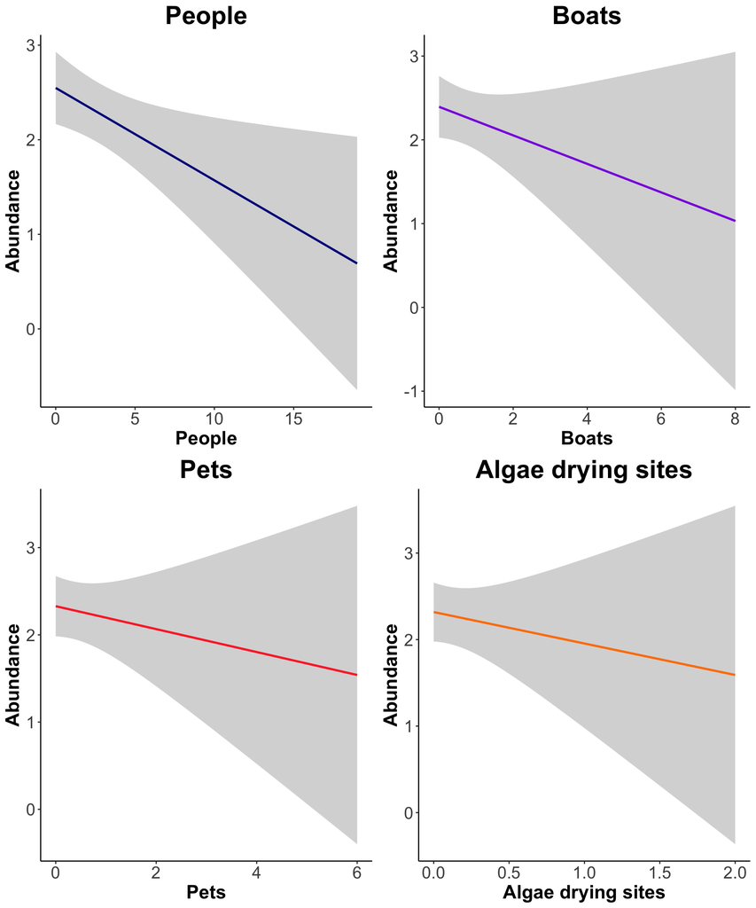

## Individual model

Although is not the best option, we will try to fit some glms for each individual predictor variable depicted in the plots above.

### People

```
##
## Call:
## glm(formula = abund ~ people)
##
## Deviance Residuals:
##     Min       1Q   Median       3Q      Max
## -2.5481  -0.8642  -0.3039   0.5251   4.9404
##
## Coefficients:
##             Estimate Std. Error t value Pr(>|t|)
## (Intercept)  2.54815    0.19497  13.069   <2e-16 ***
## people      -0.09770    0.04067  -2.402    0.019 *
## ---
## Signif. codes:  0 '***' 0.001 '**' 0.01 '*' 0.05 '.' 0.1 ' ' 1
##
## (Dispersion parameter for gaussian family taken to be 1.834821)
##
##     Null deviance: 135.36  on 69  degrees of freedom
## Residual deviance: 124.77  on 68  degrees of freedom
## AIC: 245.11
##
## Number of Fisher Scoring iterations: 2
```

### Boats

```
##
## Call:
## glm(formula = abund ~ boats)
##
## Deviance Residuals:
##     Min       1Q   Median       3Q      Max
## -2.3942  -1.1415  -0.2239   0.6058   4.7761
##
## Coefficients:
##             Estimate Std. Error t value Pr(>|t|)
## (Intercept)   2.3942     0.1880  12.738   <2e-16 ***
## boats        -0.1704     0.1379  -1.235    0.221
## ---
## Signif. codes:  0 '***' 0.001 '**' 0.01 '*' 0.05 '.' 0.1 ' ' 1
##
## (Dispersion parameter for gaussian family taken to be 1.946889)
##
##     Null deviance: 135.36  on 69  degrees of freedom
## Residual deviance: 132.39  on 68  degrees of freedom
## AIC: 249.26
##
## Number of Fisher Scoring iterations: 2
```

### Pets

```
##
## Call:
## glm(formula = abund ~ pets)
##
## Deviance Residuals:
##     Min       1Q   Median       3Q      Max
## -2.3284  -1.3284  -0.3284   0.6716   4.6716
##
## Coefficients:
##             Estimate Std. Error t value Pr(>|t|)
## (Intercept)   2.3284     0.1763  13.204   <2e-16 ***
## pets         -0.1314     0.1715  -0.766    0.446
## ---
## Signif. codes:  0 '***' 0.001 '**' 0.01 '*' 0.05 '.' 0.1 ' ' 1
##
## (Dispersion parameter for gaussian family taken to be 1.973523)
##
##     Null deviance: 135.36  on 69  degrees of freedom
## Residual deviance: 134.20  on 68  degrees of freedom
## AIC: 250.21
##
## Number of Fisher Scoring iterations: 2
```

### Algae drying sites

```
##
## Call:
## glm(formula = abund ~ algae)
##
## Deviance Residuals:
##     Min       1Q   Median       3Q      Max
## -2.3183  -1.3183  -0.3183   0.6817   4.6817
##
## Coefficients:
##             Estimate Std. Error t value Pr(>|t|)
## (Intercept)   2.3183     0.1737  13.348   <2e-16 ***
## algae        -0.3637     0.5138  -0.708    0.481
## ---
## Signif. codes:  0 '***' 0.001 '**' 0.01 '*' 0.05 '.' 0.1 ' ' 1
##
## (Dispersion parameter for gaussian family taken to be 1.976)
##
##     Null deviance: 135.36  on 69  degrees of freedom
## Residual deviance: 134.37  on 68  degrees of freedom
## AIC: 250.3
##
## Number of Fisher Scoring iterations: 2
```

## Models

```
## Linear mixed model fit by REML. t-tests use Satterthwaite's method [
## lmerModLmerTest]
## Formula: abund ~ people + boats + pets + algae + (1 | site) + (1 | month)
##
## REML criterion at convergence: 220.4
##
## Scaled residuals:
##     Min      1Q  Median      3Q     Max
## -2.2770 -0.4762 -0.1117  0.5539  3.5694
##
## Random effects:
##  Groups   Name        Variance Std.Dev.
##  month    (Intercept) 0.000    0.000
##  site     (Intercept) 1.190    1.091
##  Residual             1.021    1.010
## Number of obs: 70, groups:  month, 12; site, 6
##
## Fixed effects:
##             Estimate Std. Error       df t value Pr(>|t|)
## (Intercept)  2.28809    0.47508  5.40751   4.816  0.00391 **
## people       0.01861    0.03950 61.89226   0.471  0.63917
## boats       -0.06868    0.11303 61.43529  -0.608  0.54565
## pets        -0.02384    0.14673 60.80042  -0.162  0.87147
## algae       -0.06162    0.38604 60.81583  -0.160  0.87372
## ---
## Signif. codes:  0 '***' 0.001 '**' 0.01 '*' 0.05 '.' 0.1 ' ' 1
##
## Correlation of Fixed Effects:
##        (Intr) people boats  pets
## people -0.147
## boats  -0.113 -0.216
## pets   -0.015 -0.428  0.055
## algae  -0.096  0.012  0.128  0.071
## optimizer (nloptwrap) convergence code: 0 (OK)
## boundary (singular) fit: see ?isSingular
```

Well, it seems that none of our predictor variables are significant… Also, R warns us that we have *singular fit* (this [article](https://bbolker.github.io/mixedmodels-misc/glmmFAQ.html#singular-models-random-effect-variances-estimated-as-zero-or-correlations-estimated-as---1) to solve that).

Let’s try some multi-model inference to examine the relative support of each variable to our dataset

```
## Global model call: lmer(formula = abund ~ people + boats + pets + algae + (1 | site) +
##     (1 | month), na.action = "na.fail")
## ---
## Model selection table
##   (Intrc)    algae df   logLik   BIC delta weight
## 1   2.282           4 -105.642 228.3  0.00  0.899
## 2   2.286 -0.03779  5 -105.706 232.7  4.38  0.101
## Models ranked by BIC(x)
## Random terms (all models):
## '1 | site', '1 | month'
```

```
## $`1`
## Linear mixed model fit by REML ['lmerModLmerTest']
## Formula: abund ~ (1 | site) + (1 | month)
## REML criterion at convergence: 211.2846
## Random effects:
##  Groups   Name        Std.Dev.
##  month    (Intercept) 3.619e-05
##  site     (Intercept) 1.071e+00
##  Residual             9.839e-01
## Number of obs: 70, groups:  month, 12; site, 6
## Fixed Effects:
## (Intercept)
##       2.282
## optimizer (nloptwrap) convergence code: 0 (OK) ; 0 optimizer warnings; 1 lme4 warnings
##
## attr(,"rank")
## function (x)
## do.call("rank", list(x))
## <environment: 0x7f9e53b38200>
## attr(,"call")
## BIC(x)
## attr(,"class")
## [1] "function"     "rankFunction"
## attr(,"beta")
## [1] "none"
```

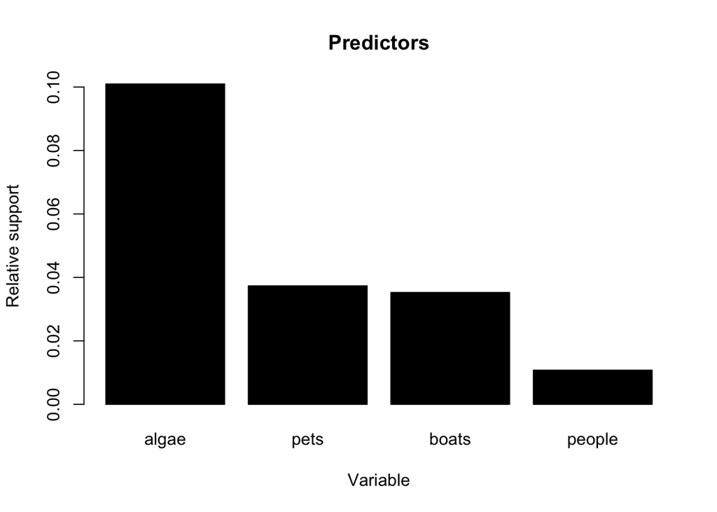

Following Ben Bolker’s advice, we can avoid singular fit by removing those random effects with a very litle contribution (in this case, *month*). Let’s try fitting a new model using only *site* as random effect:

```
## Linear mixed model fit by REML. t-tests use Satterthwaite's method [
## lmerModLmerTest]
## Formula: abund ~ people + boats + pets + algae + (1 | site)
##
## REML criterion at convergence: 220.4
##
## Scaled residuals:
##     Min      1Q  Median      3Q     Max
## -2.2770 -0.4762 -0.1117  0.5539  3.5694
##
## Random effects:
##  Groups   Name        Variance Std.Dev.
##  site     (Intercept) 1.190    1.091
##  Residual             1.021    1.010
## Number of obs: 70, groups:  site, 6
##
## Fixed effects:
##             Estimate Std. Error       df t value Pr(>|t|)
## (Intercept)  2.28809    0.47508  5.40750   4.816  0.00391 **
## people       0.01861    0.03950 61.89227   0.471  0.63917
## boats       -0.06868    0.11303 61.43529  -0.608  0.54565
## pets        -0.02384    0.14673 60.80042  -0.162  0.87147
## algae       -0.06162    0.38604 60.81583  -0.160  0.87372
## ---
## Signif. codes:  0 '***' 0.001 '**' 0.01 '*' 0.05 '.' 0.1 ' ' 1
##
## Correlation of Fixed Effects:
##        (Intr) people boats  pets
## people -0.147
## boats  -0.113 -0.216
## pets   -0.015 -0.428  0.055
## algae  -0.096  0.012  0.128  0.071
```

Well, there is no singular fit now, BUT none of our predictor variables is significant (doh!)

Let’s examine multi-model inference for this new model as well:

```
## Global model call: lmer(formula = abund ~ people + boats + pets + algae + (1 | site),
##     na.action = "na.fail")
## ---
## Model selection table
##   (Intrc)    algae df   logLik   BIC delta weight
## 1   2.282           3 -105.642 224.0  0.00  0.899
## 2   2.286 -0.03779  4 -105.706 228.4  4.38  0.101
## Models ranked by BIC(x)
## Random terms (all models):
## '1 | site'
```

```
## $`1`
## Linear mixed model fit by REML ['lmerModLmerTest']
## Formula: abund ~ (1 | site)
## REML criterion at convergence: 211.2846
## Random effects:
##  Groups   Name        Std.Dev.
##  site     (Intercept) 1.0706
##  Residual             0.9839
## Number of obs: 70, groups:  site, 6
## Fixed Effects:
## (Intercept)
##       2.282
##
## attr(,"rank")
## function (x)
## do.call("rank", list(x))
## <environment: 0x7f9e4d2c7f38>
## attr(,"call")
## BIC(x)
## attr(,"class")
## [1] "function"     "rankFunction"
## attr(,"beta")
## [1] "none"
```

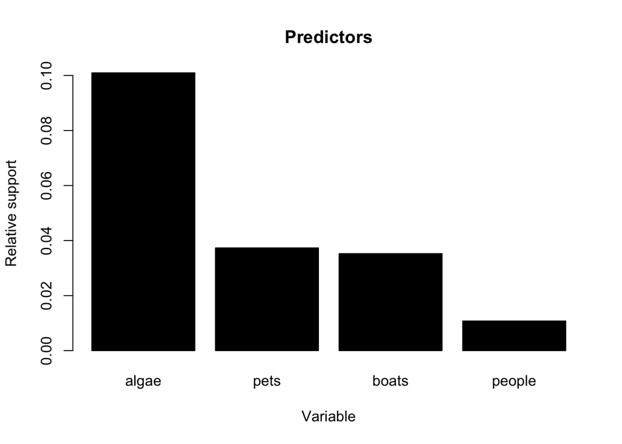

### A Bayesian approach

```
##
##  Iterations = 3001:12991
##  Thinning interval  = 10
##  Sample size  = 1000
##
##  DIC: 212.1277
##
##  G-structure:  ~site
##
##      post.mean l-95% CI u-95% CI eff.samp
## site     1.927   0.1741    5.097     1000
##
##  R-structure:  ~units
##
##       post.mean l-95% CI u-95% CI eff.samp
## units      1.05   0.7042     1.45     1000
##
##  Location effects: abund ~ people + boats + pets + algae
##
##             post.mean l-95% CI u-95% CI eff.samp pMCMC
## (Intercept)   2.29642  1.08415  3.43559     1000 0.004 **
## people        0.01738 -0.06011  0.09440     1000 0.652
## boats        -0.07226 -0.29013  0.14713     1000 0.560
## pets         -0.02465 -0.31782  0.24226     1000 0.846
## algae        -0.04857 -0.75138  0.79824     1000 0.880
## ---
## Signif. codes:  0 '***' 0.001 '**' 0.01 '*' 0.05 '.' 0.1 ' ' 1
```

OK, it seems that there is no effect at all, as both approaches showed consistent results.